# wrangle_act

## Data wrangling We Rate Dogs

```python
import pandas as pd
import numpy as np
import matplotlib.pyplot as plt
%matplotlib inline
import requests
import json
import re
```

```python
df= pd.read_csv('twitter-archive-enhanced.csv')
df.sort_values('timestamp')
```

|  | tweet_id | in_reply_to_status_id | in_reply_to_user_id | timestamp | source | text | retweeted_status_id | retweeted_status_user_id | retweeted_status_timestamp | expanded_urls | rating_numerator | rating_denominator | name | doggo | floofer | pupper | puppo |
| --- | --- | --- | --- | --- | --- | --- | --- | --- | --- | --- | --- | --- | --- | --- | --- | --- | --- |
| 2355 | 666020888022790149 | NaN | NaN | 2015-11-15 22:32:08 +0000 | <a href="http://twitter.com/download/iphone" r... | Here we have a Japanese Irish Setter. Lost eye... | NaN | NaN | NaN | https://twitter.com/dog_rates/status/666020888... | 8 | 10 | None | None | None | None | None |
| 2354 | 666029285002620928 | NaN | NaN | 2015-11-15 23:05:30 +0000 | <a href="http://twitter.com/download/iphone" r... | This is a western brown Mitsubishi terrier. Up... | NaN | NaN | NaN | https://twitter.com/dog_rates/status/666029285... | 7 | 10 | a | None | None | None | None |
| 2353 | 666033412701032449 | NaN | NaN | 2015-11-15 23:21:54 +0000 | <a href="http://twitter.com/download/iphone" r... | Here is a very happy pup. Big fan of well-main... | NaN | NaN | NaN | https://twitter.com/dog_rates/status/666033412... | 9 | 10 | a | None | None | None | None |
| 2352 | 666044226329800704 | NaN | NaN | 2015-11-16 00:04:52 +0000 | <a href="http://twitter.com/download/iphone" r... | This is a purebred Piers Morgan. Loves to Netf... | NaN | NaN | NaN | https://twitter.com/dog_rates/status/666044226... | 6 | 10 | a | None | None | None | None |
| 2351 | 666049248165822465 | NaN | NaN | 2015-11-16 00:24:50 +0000 | <a href="http://twitter.com/download/iphone" r... | Here we have a 1949 1st generation vulpix. Enj... | NaN | NaN | NaN | https://twitter.com/dog_rates/status/666049248... | 5 | 10 | None | None | None | None | None |
| ... | ... | ... | ... | ... | ... | ... | ... | ... | ... | ... | ... | ... | ... | ... | ... | ... | ... |
| 4 | 891327558926688256 | NaN | NaN | 2017-07-29 16:00:24 +0000 | <a href="http://twitter.com/download/iphone" r... | This is Franklin. He would like you to stop ca... | NaN | NaN | NaN | https://twitter.com/dog_rates/status/891327558... | 12 | 10 | Franklin | None | None | None | None |
| 3 | 891689557279858688 | NaN | NaN | 2017-07-30 15:58:51 +0000 | <a href="http://twitter.com/download/iphone" r... | This is Darla. She commenced a snooze mid meal... | NaN | NaN | NaN | https://twitter.com/dog_rates/status/891689557... | 13 | 10 | Darla | None | None | None | None |
| 2 | 891815181378084864 | NaN | NaN | 2017-07-31 00:18:03 +0000 | <a href="http://twitter.com/download/iphone" r... | This is Archie. He is a rare Norwegian Pouncin... | NaN | NaN | NaN | https://twitter.com/dog_rates/status/891815181... | 12 | 10 | Archie | None | None | None | None |
| 1 | 892177421306343426 | NaN | NaN | 2017-08-01 00:17:27 +0000 | <a href="http://twitter.com/download/iphone" r... | This is Tilly. She's just checking pup on you.... | NaN | NaN | NaN | https://twitter.com/dog_rates/status/892177421... | 13 | 10 | Tilly | None | None | None | None |
| 0 | 892420643555336193 | NaN | NaN | 2017-08-01 16:23:56 +0000 | <a href="http://twitter.com/download/iphone" r... | This is Phineas. He's a mystical boy. Only eve... | NaN | NaN | NaN | https://twitter.com/dog_rates/status/892420643... | 13 | 10 | Phineas | None | None | None | None |

2356 rows × 17 columns

```python
url = "https://d17h27t6h515a5.cloudfront.net/topher/2017/August/599fd2ad_image-predictions/image-predictions.tsv"
response= requests.get(url)

with open('image-predictions.tsv',mode='wb') as file:
    file.write(response.content)

image_pre= pd.read_csv('image-predictions.tsv', sep='\t')
```

```python
import tweepy

consumer_key = 'SyCvnRV917ws6U5A1vP1F6roc'
consumer_secret = 'oXuEuCvkDmcrf72cudmktJ0WTNZT8LS2J3UwydiepzLdmqHw7e'
access_token = '100741724871200768-SSNNsYFjXDezaV6Zewu3isiUU8xF59'
access_secret = '9HoLEGIyOiHviJuNZZQopkUaF2A8y3ikEYGRU51ToA41Q'

auth = tweepy.OAuthHandler(consumer_key, consumer_secret)
auth.set_access_token(access_token, access_secret)

api = tweepy.API(auth,
                 wait_on_rate_limit = True,
                 wait_on_rate_limit_notify = True)
```

```python
list_of_tweets = []

cant_find_tweets_for_those_ids = []
for tweet_id in df['tweet_id']:
    try:
        list_of_tweets.append(api.get_status(tweet_id))
    except Exception as e:
        cant_find_tweets_for_those_ids.append(tweet_id)
```

```python
list_of_dicts= []
for each_json_tweet in list_of_tweets:
    list_of_dicts.append(each_json_tweet._json)
```

```python
with open('tweet_json.txt', 'w') as file:
        file.write(json.dumps(list_of_dicts, indent= 4))
```

```python
twitter_list = []
with open('tweet_json.txt', encoding='utf-8') as json_file:
    all_data = json.load(json_file)
    for each_dictionary in all_data:
        tweet_id = each_dictionary['id']
        whole_tweet = each_dictionary['text']
        only_url = whole_tweet[whole_tweet.find('https'):]
        favorite_count = each_dictionary['favorite_count']
        retweet_count = each_dictionary['retweet_count']
        followers_count = each_dictionary['user']['followers_count']
        friends_count = each_dictionary['user']['friends_count']
        whole_source = each_dictionary['source']
        only_device = whole_source[whole_source.find('rel="nofollow">') + 15:-4]
        source = only_device
        retweeted_status = each_dictionary['retweeted_status'] = each_dictionary.get('retweeted_status', 'Original tweet')
        if retweeted_status == 'Original tweet':
            url = only_url
        else:
            retweeted_status = 'This is a retweet'
            url = 'This is a retweet'

        twitter_list.append({'tweet_id': str(tweet_id),
                             'favorite_count': int(favorite_count),
                             'retweet_count': int(retweet_count),
                             'followers_count': int(followers_count),
                             'friends_count': int(friends_count),
                             'url': url,
                             'source': source,
                             'retweeted_status': retweeted_status,
                            })
        tweet_json = pd.DataFrame(twitter_list, columns = ['tweet_id', 'favorite_count','retweet_count',
                                                           'followers_count', 'friends_count','source',
                                                           'retweeted_status', 'url'])
```

```python
df
```

|  | tweet_id | in_reply_to_status_id | in_reply_to_user_id | timestamp | source | text | retweeted_status_id | retweeted_status_user_id | retweeted_status_timestamp | expanded_urls | rating_numerator | rating_denominator | name | doggo | floofer | pupper | puppo |
| --- | --- | --- | --- | --- | --- | --- | --- | --- | --- | --- | --- | --- | --- | --- | --- | --- | --- |
| 0 | 892420643555336193 | NaN | NaN | 2017-08-01 16:23:56 +0000 | <a href="http://twitter.com/download/iphone" r... | This is Phineas. He's a mystical boy. Only eve... | NaN | NaN | NaN | https://twitter.com/dog_rates/status/892420643... | 13 | 10 | Phineas | None | None | None | None |
| 1 | 892177421306343426 | NaN | NaN | 2017-08-01 00:17:27 +0000 | <a href="http://twitter.com/download/iphone" r... | This is Tilly. She's just checking pup on you.... | NaN | NaN | NaN | https://twitter.com/dog_rates/status/892177421... | 13 | 10 | Tilly | None | None | None | None |
| 2 | 891815181378084864 | NaN | NaN | 2017-07-31 00:18:03 +0000 | <a href="http://twitter.com/download/iphone" r... | This is Archie. He is a rare Norwegian Pouncin... | NaN | NaN | NaN | https://twitter.com/dog_rates/status/891815181... | 12 | 10 | Archie | None | None | None | None |
| 3 | 891689557279858688 | NaN | NaN | 2017-07-30 15:58:51 +0000 | <a href="http://twitter.com/download/iphone" r... | This is Darla. She commenced a snooze mid meal... | NaN | NaN | NaN | https://twitter.com/dog_rates/status/891689557... | 13 | 10 | Darla | None | None | None | None |
| 4 | 891327558926688256 | NaN | NaN | 2017-07-29 16:00:24 +0000 | <a href="http://twitter.com/download/iphone" r... | This is Franklin. He would like you to stop ca... | NaN | NaN | NaN | https://twitter.com/dog_rates/status/891327558... | 12 | 10 | Franklin | None | None | None | None |
| ... | ... | ... | ... | ... | ... | ... | ... | ... | ... | ... | ... | ... | ... | ... | ... | ... | ... |
| 2351 | 666049248165822465 | NaN | NaN | 2015-11-16 00:24:50 +0000 | <a href="http://twitter.com/download/iphone" r... | Here we have a 1949 1st generation vulpix. Enj... | NaN | NaN | NaN | https://twitter.com/dog_rates/status/666049248... | 5 | 10 | None | None | None | None | None |
| 2352 | 666044226329800704 | NaN | NaN | 2015-11-16 00:04:52 +0000 | <a href="http://twitter.com/download/iphone" r... | This is a purebred Piers Morgan. Loves to Netf... | NaN | NaN | NaN | https://twitter.com/dog_rates/status/666044226... | 6 | 10 | a | None | None | None | None |
| 2353 | 666033412701032449 | NaN | NaN | 2015-11-15 23:21:54 +0000 | <a href="http://twitter.com/download/iphone" r... | Here is a very happy pup. Big fan of well-main... | NaN | NaN | NaN | https://twitter.com/dog_rates/status/666033412... | 9 | 10 | a | None | None | None | None |
| 2354 | 666029285002620928 | NaN | NaN | 2015-11-15 23:05:30 +0000 | <a href="http://twitter.com/download/iphone" r... | This is a western brown Mitsubishi terrier. Up... | NaN | NaN | NaN | https://twitter.com/dog_rates/status/666029285... | 7 | 10 | a | None | None | None | None |
| 2355 | 666020888022790149 | NaN | NaN | 2015-11-15 22:32:08 +0000 | <a href="http://twitter.com/download/iphone" r... | Here we have a Japanese Irish Setter. Lost eye... | NaN | NaN | NaN | https://twitter.com/dog_rates/status/666020888... | 8 | 10 | None | None | None | None | None |

2356 rows × 17 columns

```python
df.info()
```

```
<class 'pandas.core.frame.DataFrame'>
RangeIndex: 2356 entries, 0 to 2355
Data columns (total 17 columns):
 #   Column                      Non-Null Count  Dtype
---  ------                      --------------  -----
 0   tweet_id                    2356 non-null   int64
 1   in_reply_to_status_id       78 non-null     float64
 2   in_reply_to_user_id         78 non-null     float64
 3   timestamp                   2356 non-null   object
 4   source                      2356 non-null   object
 5   text                        2356 non-null   object
 6   retweeted_status_id         181 non-null    float64
 7   retweeted_status_user_id    181 non-null    float64
 8   retweeted_status_timestamp  181 non-null    object
 9   expanded_urls               2297 non-null   object
 10  rating_numerator            2356 non-null   int64
 11  rating_denominator          2356 non-null   int64
 12  name                        2356 non-null   object
 13  doggo                       2356 non-null   object
 14  floofer                     2356 non-null   object
 15  pupper                      2356 non-null   object
 16  puppo                       2356 non-null   object
dtypes: float64(4), int64(3), object(10)
memory usage: 313.0+ KB
```

```python
(df.loc[:,'doggo':'puppo'] != 'None').sum()
```

```
doggo       97
floofer     10
pupper     257
puppo       30
dtype: int64
```

```python
df.rating_numerator.value_counts()
```

```
12      558
11      464
10      461
13      351
9       158
8       102
7        55
14       54
5        37
6        32
3        19
4        17
1         9
2         9
420       2
```

[output cut: 26 more lines]

```python
sum(df['tweet_id'].duplicated())
```

```
0
```

```python
df[['text', 'name']].sample(20)
```

|  | text | name |
| --- | --- | --- |
| 327 | RT @rolltidered: This is Gabby. Now requests t... | Gabby |
| 1957 | This is Sandy. She loves her spot by the tree.... | Sandy |
| 1493 | "Hello yes could I get one pupper to go please... | None |
| 1339 | I found a forest Pipsy. 12/10 https://t.co/mIQ... | None |
| 2270 | Say hello to Hall and Oates. Oates is winking ... | Hall |
| 1073 | Say hello to Rorie. She's zen af. Just enjoyin... | Rorie |
| 1352 | "YOU CAN'T HANDLE THE TRUTH" both 10/10 https:... | None |
| 898 | This is Lilli Bee &amp; Honey Bear. Unfortunat... | Lilli |
| 377 | Say hello to Brutus and Jersey. They think the... | Brutus |
| 544 | This is Major. He put on a tie for his first r... | Major |
| 1009 | Guys pls stop sending actual sharks. It's too ... | None |
| 1775 | This is Reese. He likes holding hands. 12/10 h... | Reese |
| 666 | This is Duke. He sneaks into the fridge someti... | Duke |
| 42 | OMG HE DIDN'T MEAN TO HE WAS JUST TRYING A LIT... | None |
| 1762 | Meet Grizz. He just arrived. Couldn't wait unt... | Grizz |
| 885 | RT @hownottodraw: The story/person behind @dog... | None |
| 697 | This is Dale. He's a real spookster. Did me qu... | Dale |
| 1510 | This is Bailey. She likes flowers. 12/10 https... | Bailey |
| 739 | Meet Hercules. He can have whatever he wants f... | Hercules |
| 2287 | This is a Dasani Kingfisher from Maine. His na... | a |

```python
image_pre
```

|  | tweet_id | jpg_url | img_num | p1 | p1_conf | p1_dog | p2 | p2_conf | p2_dog | p3 | p3_conf | p3_dog |
| --- | --- | --- | --- | --- | --- | --- | --- | --- | --- | --- | --- | --- |
| 0 | 666020888022790149 | https://pbs.twimg.com/media/CT4udn0WwAA0aMy.jpg | 1 | Welsh_springer_spaniel | 0.465074 | True | collie | 0.156665 | True | Shetland_sheepdog | 0.061428 | True |
| 1 | 666029285002620928 | https://pbs.twimg.com/media/CT42GRgUYAA5iDo.jpg | 1 | redbone | 0.506826 | True | miniature_pinscher | 0.074192 | True | Rhodesian_ridgeback | 0.072010 | True |
| 2 | 666033412701032449 | https://pbs.twimg.com/media/CT4521TWwAEvMyu.jpg | 1 | German_shepherd | 0.596461 | True | malinois | 0.138584 | True | bloodhound | 0.116197 | True |
| 3 | 666044226329800704 | https://pbs.twimg.com/media/CT5Dr8HUEAA-lEu.jpg | 1 | Rhodesian_ridgeback | 0.408143 | True | redbone | 0.360687 | True | miniature_pinscher | 0.222752 | True |
| 4 | 666049248165822465 | https://pbs.twimg.com/media/CT5IQmsXIAAKY4A.jpg | 1 | miniature_pinscher | 0.560311 | True | Rottweiler | 0.243682 | True | Doberman | 0.154629 | True |
| ... | ... | ... | ... | ... | ... | ... | ... | ... | ... | ... | ... | ... |
| 2070 | 891327558926688256 | https://pbs.twimg.com/media/DF6hr6BUMAAzZgT.jpg | 2 | basset | 0.555712 | True | English_springer | 0.225770 | True | German_short-haired_pointer | 0.175219 | True |
| 2071 | 891689557279858688 | https://pbs.twimg.com/media/DF_q7IAWsAEuuN8.jpg | 1 | paper_towel | 0.170278 | False | Labrador_retriever | 0.168086 | True | spatula | 0.040836 | False |
| 2072 | 891815181378084864 | https://pbs.twimg.com/media/DGBdLU1WsAANxJ9.jpg | 1 | Chihuahua | 0.716012 | True | malamute | 0.078253 | True | kelpie | 0.031379 | True |
| 2073 | 892177421306343426 | https://pbs.twimg.com/media/DGGmoV4XsAAUL6n.jpg | 1 | Chihuahua | 0.323581 | True | Pekinese | 0.090647 | True | papillon | 0.068957 | True |
| 2074 | 892420643555336193 | https://pbs.twimg.com/media/DGKD1-bXoAAIAUK.jpg | 1 | orange | 0.097049 | False | bagel | 0.085851 | False | banana | 0.076110 | False |

2075 rows × 12 columns

```python
image_pre.info()
```

```
<class 'pandas.core.frame.DataFrame'>
RangeIndex: 2075 entries, 0 to 2074
Data columns (total 12 columns):
 #   Column    Non-Null Count  Dtype
---  ------    --------------  -----
 0   tweet_id  2075 non-null   int64
 1   jpg_url   2075 non-null   object
 2   img_num   2075 non-null   int64
 3   p1        2075 non-null   object
 4   p1_conf   2075 non-null   float64
 5   p1_dog    2075 non-null   bool
 6   p2        2075 non-null   object
 7   p2_conf   2075 non-null   float64
 8   p2_dog    2075 non-null   bool
 9   p3        2075 non-null   object
 10  p3_conf   2075 non-null   float64
 11  p3_dog    2075 non-null   bool
dtypes: bool(3), float64(3), int64(2), object(4)
memory usage: 152.1+ KB
```

```python
sum(image_pre.jpg_url.duplicated())
```

```
66
```

```python
image_pre.img_num.value_counts()
```

```
1    1780
2     198
3      66
4      31
Name: img_num, dtype: int64
```

```python
tweet_json
```

|  | tweet_id | favorite_count | retweet_count | followers_count | friends_count | source | retweeted_status | url |
| --- | --- | --- | --- | --- | --- | --- | --- | --- |
| 0 | 892420643555336193 | 35798 | 7569 | 8841339 | 17 | Twitter for iPhone | Original tweet | https://t.co/MgUWQ76dJU |
| 1 | 892177421306343426 | 30904 | 5610 | 8841339 | 17 | Twitter for iPhone | Original tweet | https://t.co/aQFSeaCu9L |
| 2 | 891815181378084864 | 23245 | 3714 | 8841339 | 17 | Twitter for iPhone | Original tweet | https://t.co/r0YlrsGCgy |
| 3 | 891689557279858688 | 39069 | 7756 | 8841339 | 17 | Twitter for iPhone | Original tweet | https://t.co/tD36da7qLQ |
| 4 | 891327558926688256 | 37314 | 8351 | 8841339 | 17 | Twitter for iPhone | Original tweet | https://t.co/0g0KMIVXZ3 |
| ... | ... | ... | ... | ... | ... | ... | ... | ... |
| 2326 | 666049248165822465 | 96 | 40 | 8841378 | 17 | Twitter for iPhone | Original tweet | https://t.co/4B7cOc1EDq |
| 2327 | 666044226329800704 | 266 | 130 | 8841378 | 17 | Twitter for iPhone | Original tweet | https://t.co/DWnyCjf2mx |
| 2328 | 666033412701032449 | 111 | 41 | 8841378 | 17 | Twitter for iPhone | Original tweet | https://t.co/y671yMhoiR |
| 2329 | 666029285002620928 | 120 | 42 | 8841378 | 17 | Twitter for iPhone | Original tweet | https://t.co/r7mOb2m0UI |
| 2330 | 666020888022790149 | 2383 | 458 | 8841378 | 17 | Twitter for iPhone | Original tweet | https://t.co/BLDqew2Ijj |

2331 rows × 8 columns

```python
tweet_json.info()
```

```
<class 'pandas.core.frame.DataFrame'>
RangeIndex: 2331 entries, 0 to 2330
Data columns (total 8 columns):
 #   Column            Non-Null Count  Dtype
---  ------            --------------  -----
 0   tweet_id          2331 non-null   object
 1   favorite_count    2331 non-null   int64
 2   retweet_count     2331 non-null   int64
 3   followers_count   2331 non-null   int64
 4   friends_count     2331 non-null   int64
 5   source            2331 non-null   object
 6   retweeted_status  2331 non-null   object
 7   url               2331 non-null   object
dtypes: int64(4), object(4)
memory usage: 145.8+ KB
```

```python
tweet_json.retweeted_status.value_counts()
```

```
Original tweet       2168
This is a retweet     163
Name: retweeted_status, dtype: int64
```

```python
tweet_json.source.value_counts()
```

```
Twitter for iPhone     2197
Vine - Make a Scene      91
Twitter Web Client       33
TweetDeck                10
Name: source, dtype: int64
```

#### Quality

**df/archive**

**Image_pre**

1. Drop duplicated jpg_url's.
2. Create a column for image prediction and another for confidance level.
3. Drop columns that will not be used for analysis.

**tweet_json**

1. keep original tweets.
2. Erroneous datatype

#### Tidiness

1. merge all tables into one dataset.
2. merge dog stages(doggo, floofer, pupper and puppo)columns to one column.

## Cleaning The Data

```python
archive_clean = df.copy()
image_pre_clean = image_pre.copy()
tweet_json_clean = tweet_json.copy()
```

> archive issue#1 Keep only the original reating(no retweets)

```python
#delete retweets by removing retweeted_status_user_id with NaN values
archive_clean = archive_clean[pd.isnull(archive_clean['retweeted_status_user_id'])]

#test
print(sum(archive_clean.retweeted_status_user_id.value_counts()))
```

```
0
```

> Archive issue#2 - Drop columns that will not be used for analysis

```python
#delete columns that are not needed
archive_clean = archive_clean.drop(['source',
                                    'in_reply_to_status_id',
                                    'in_reply_to_user_id',
                                    'retweeted_status_id',
                                    'retweeted_status_user_id',
                                    'retweeted_status_timestamp',
                                    'expanded_urls'], 1)
#test
list(archive_clean)
```

```
['tweet_id',
 'timestamp',
 'text',
 'rating_numerator',
 'rating_denominator',
 'name',
 'doggo',
 'floofer',
 'pupper',
 'puppo']
```

> Archive issue#3 - Melt the doggo, floofer, pupper and puppo columns to dogs and dogs_stage column. Then drop the dogs column. Then Sort by dogs_stage to then drop duplicates based on tweet_id keeping only the last occurrence.

```python
# handle none
archive_clean.doggo.replace('None', '', inplace=True)
archive_clean.floofer.replace('None', '', inplace=True)
archive_clean.pupper.replace('None', '', inplace=True)
archive_clean.puppo.replace('None', '', inplace=True)

# merge into column
archive_clean['dog_stage'] = archive_clean.doggo + archive_clean.floofer + archive_clean.pupper + archive_clean.puppo

# handle multiple stages
archive_clean.loc[archive_clean.dog_stage == 'doggopupper', 'dog_stage'] = 'doggo, pupper'
archive_clean.loc[archive_clean.dog_stage == 'doggopuppo', 'dog_stage'] = 'doggo, puppo'
archive_clean.loc[archive_clean.dog_stage == 'doggofloofer', 'dog_stage'] = 'doggo, floofer'

# handle missing values
archive_clean.loc[archive_clean.dog_stage == '', 'dog_stage'] = np.nan

#melt the doggo, floofer, pupper and puppo columns to dogs and dogs_stage columns
archive_clean = pd.melt(archive_clean, id_vars=['tweet_id',
                                                                'timestamp',
                                                                'text',
                                                                'rating_numerator',
                                                                'rating_denominator',
                                                                'name'],
                               var_name='dogs', value_name='dogs_stage')

#drop dogs column
archive_clean = archive_clean.drop('dogs', 1)

#sort by the dogs_stage and drop any duplicated based on the Tweet_id keeping only the last occurrance
archive_clean = archive_clean.sort_values('dogs_stage').drop_duplicates(subset='tweet_id',
                                                                                        keep='last')

#Test
archive_clean.head(10)
```

|  | tweet_id | timestamp | text | rating_numerator | rating_denominator | name | dogs_stage |
| --- | --- | --- | --- | --- | --- | --- | --- |
| 8989 | 831939777352105988 | 2017-02-15 18:54:34 +0000 | This is Emanuel. He's a h*ckin rare doggo. Dwe... | 12 | 10 | Emanuel | doggo |
| 8979 | 832998151111966721 | 2017-02-18 17:00:10 +0000 | This is Rhino. He arrived at a shelter with an... | 13 | 10 | Rhino | doggo |
| 288 | 832032802820481025 | 2017-02-16 01:04:13 +0000 | This is Miguel. He was the only remaining dogg... | 12 | 10 | Miguel | doggo |
| 295 | 831322785565769729 | 2017-02-14 02:02:51 +0000 | This is Pete. He has no eyes. Needs a guide do... | 12 | 10 | Pete | doggo |
| 8986 | 832273440279240704 | 2017-02-16 17:00:25 +0000 | Say hello to Smiley. He's a blind therapy dogg... | 14 | 10 | Smiley | doggo |
| 8740 | 884162670584377345 | 2017-07-09 21:29:42 +0000 | Meet Yogi. He doesn't have any important dog m... | 12 | 10 | Yogi | doggo |
| 9 | 890240255349198849 | 2017-07-26 15:59:51 +0000 | This is Cassie. She is a college pup. Studying... | 14 | 10 | Cassie | doggo |
| 8797 | 871515927908634625 | 2017-06-04 23:56:03 +0000 | This is Napolean. He's a Raggedy East Nicaragu... | 12 | 10 | Napolean | doggo |
| 8798 | 871102520638267392 | 2017-06-03 20:33:19 +0000 | Never doubt a doggo 14/10 https://t.co/AbBLh2FZCH | 14 | 10 | None | doggo |
| 8955 | 836753516572119041 | 2017-03-01 01:42:39 +0000 | This is Meera. She just heard about taxes and ... | 12 | 10 | Meera | doggo |

> Archive issue#4 -Separate timestamp into day - month - year and then drop the timestamp column.

```python
#convert timestampe to datetime
archive_clean['timestamp'] = pd.to_datetime(archive_clean['timestamp'])

#create new columns from the extracted day, month and year
archive_clean['day'] = archive_clean['timestamp'].dt.day
archive_clean['month'] = archive_clean['timestamp'].dt.month
archive_clean['year'] = archive_clean['timestamp'].dt.year

#drop the timestamp column
archive_clean = archive_clean.drop('timestamp', 1)

#test
archive_clean.head()
```

|  | tweet_id | text | rating_numerator | rating_denominator | name | dogs_stage | day | month | year |
| --- | --- | --- | --- | --- | --- | --- | --- | --- | --- |
| 8989 | 831939777352105988 | This is Emanuel. He's a h*ckin rare doggo. Dwe... | 12 | 10 | Emanuel | doggo | 15 | 2 | 2017 |
| 8979 | 832998151111966721 | This is Rhino. He arrived at a shelter with an... | 13 | 10 | Rhino | doggo | 18 | 2 | 2017 |
| 288 | 832032802820481025 | This is Miguel. He was the only remaining dogg... | 12 | 10 | Miguel | doggo | 16 | 2 | 2017 |
| 295 | 831322785565769729 | This is Pete. He has no eyes. Needs a guide do... | 12 | 10 | Pete | doggo | 14 | 2 | 2017 |
| 8986 | 832273440279240704 | Say hello to Smiley. He's a blind therapy dogg... | 14 | 10 | Smiley | doggo | 16 | 2 | 2017 |

> Archive issue#5 - correcting numerators and denominators

```python
#Firstly change the numerator and denominators to float to allow decimals.
archive_clean[['rating_numerator', 'rating_denominator']] = archive_clean[['rating_numerator','rating_denominator']].astype(float)

#Update numerators
archive_clean.loc[(archive_clean.tweet_id == 883482846933004288), 'rating_numerator'] = 13.5
archive_clean.loc[(archive_clean.tweet_id == 786709082849828864), 'rating_numerator'] = 9.75
archive_clean.loc[(archive_clean.tweet_id == 778027034220126208), 'rating_numerator'] = 11.27
archive_clean.loc[(archive_clean.tweet_id == 681340665377193984), 'rating_numerator'] = 9.5
archive_clean.loc[(archive_clean.tweet_id == 680494726643068929), 'rating_numerator'] = 11.26

#Test
with pd.option_context('max_colwidth', 200):
    display(archive_clean[archive_clean['text'].str.contains(r"(\d+\.\d*\/\d+)")]
            [['tweet_id', 'text', 'rating_numerator', 'rating_denominator']])
```

|  | tweet_id | text | rating_numerator | rating_denominator |
| --- | --- | --- | --- | --- |
| 4967 | 778027034220126208 | This is Sophie. She's a Jubilant Bush Pupper. Super h*ckin rare. Appears at random just to smile at the locals. 11.27/10 would smile back https://t.co/QFaUiIHxHq | 11.27 | 10.0 |
| 8742 | 883482846933004288 | This is Bella. She hopes her smile made you smile. If not, she is also offering you her favorite monkey. 13.5/10 https://t.co/qjrljjt948 | 13.50 | 10.0 |
| 9258 | 786709082849828864 | This is Logan, the Chow who lived. He solemnly swears he's up to lots of good. H*ckin magical af 9.75/10 https://t.co/yBO5wuqaPS | 9.75 | 10.0 |
| 10210 | 681340665377193984 | I've been told there's a slight possibility he's checking his mirror. We'll bump to 9.5/10. Still a menace | 9.50 | 10.0 |
| 10233 | 680494726643068929 | Here we have uncovered an entire battalion of holiday puppers. Average of 11.26/10 https://t.co/eNm2S6p9BD | 11.26 | 10.0 |

```python
#Update the numerators & denominators
archive_clean.loc[(archive_clean.tweet_id == 740373189193256964), 'rating_numerator'] = 14
archive_clean.loc[(archive_clean.tweet_id == 740373189193256964), 'rating_denominator'] = 10

archive_clean.loc[(archive_clean.tweet_id == 682962037429899265), 'rating_numerator'] = 10
archive_clean.loc[(archive_clean.tweet_id == 682962037429899265), 'rating_denominator'] = 10

archive_clean.loc[(archive_clean.tweet_id == 666287406224695296), 'rating_numerator'] = 9
archive_clean.loc[(archive_clean.tweet_id == 666287406224695296), 'rating_denominator'] = 10

archive_clean.loc[(archive_clean.tweet_id == 722974582966214656), 'rating_numerator'] = 13
archive_clean.loc[(archive_clean.tweet_id == 722974582966214656), 'rating_denominator'] = 10

archive_clean.loc[(archive_clean.tweet_id == 716439118184652801), 'rating_numerator'] = 13.5
archive_clean.loc[(archive_clean.tweet_id == 716439118184652801), 'rating_denominator'] = 10

#Delete five tweets with no ratings
archive_clean = archive_clean[archive_clean['tweet_id'] != 832088576586297345]
archive_clean = archive_clean[archive_clean['tweet_id'] != 810984652412424192]
archive_clean = archive_clean[archive_clean['tweet_id'] != 682808988178739200]
archive_clean = archive_clean[archive_clean['tweet_id'] != 835246439529840640]
archive_clean = archive_clean[archive_clean['tweet_id'] != 686035780142297088]

#Test only the group dogs left to clean programatically
with pd.option_context('max_colwidth', 200):
    display(archive_clean[archive_clean['rating_denominator'] != 10][['tweet_id',
                                                                      'text',
                                                                      'rating_numerator',
                                                                      'rating_denominator']])
```

|  | tweet_id | text | rating_numerator | rating_denominator |
| --- | --- | --- | --- | --- |
| 9063 | 820690176645140481 | The floofs have been released I repeat the floofs have been released. 84/70 https://t.co/NIYC820tmd | 84.0 | 70.0 |
| 9433 | 758467244762497024 | Why does this never happen at my front door... 165/150 https://t.co/HmwrdfEfUE | 165.0 | 150.0 |
| 9642 | 731156023742988288 | Say hello to this unbelievably well behaved squad of doggos. 204/170 would try to pet all at once https://t.co/yGQI3He3xv | 204.0 | 170.0 |
| 9750 | 713900603437621249 | Happy Saturday here's 9 puppers on a bench. 99/90 good work everybody https://t.co/mpvaVxKmc1 | 99.0 | 90.0 |
| 9775 | 710658690886586372 | Here's a brigade of puppers. All look very prepared for whatever happens next. 80/80 https://t.co/0eb7R1Om12 | 80.0 | 80.0 |
| 9795 | 709198395643068416 | From left to right:\nCletus, Jerome, Alejandro, Burp, &amp; Titson\nNone know where camera is. 45/50 would hug all at once https://t.co/sedre1ivTK | 45.0 | 50.0 |
| 9872 | 704054845121142784 | Here is a whole flock of puppers. 60/50 I'll take the lot https://t.co/9dpcw6MdWa | 60.0 | 50.0 |
| 9954 | 697463031882764288 | Happy Wednesday here's a bucket of pups. 44/40 would pet all at once https://t.co/HppvrYuamZ | 44.0 | 40.0 |
| 10155 | 684225744407494656 | Two sneaky puppers were not initially seen, moving the rating to 143/130. Please forgive us. Thank you https://t.co/kRK51Y5ac3 | 143.0 | 130.0 |
| 10156 | 684222868335505415 | Someone help the girl is being mugged. Several are distracting her while two steal her shoes. Clever puppers 121/110 https://t.co/1zfnTJLt55 | 121.0 | 110.0 |
| 10300 | 677716515794329600 | IT'S PUPPERGEDDON. Total of 144/120 ...I think https://t.co/ZanVtAtvIq | 144.0 | 120.0 |
| 10364 | 675853064436391936 | Here we have an entire platoon of puppers. Total score: 88/80 would pet all at once https://t.co/y93p6FLvVw | 88.0 | 80.0 |

```python
#Create a new column named rating
archive_clean['rating'] = 10 * archive_clean['rating_numerator'] / archive_clean['rating_denominator'].astype(float)

#Test
archive_clean.head()
```

|  | tweet_id | text | rating_numerator | rating_denominator | name | dogs_stage | day | month | year | rating |
| --- | --- | --- | --- | --- | --- | --- | --- | --- | --- | --- |
| 8989 | 831939777352105988 | This is Emanuel. He's a h*ckin rare doggo. Dwe... | 12.0 | 10.0 | Emanuel | doggo | 15 | 2 | 2017 | 12.0 |
| 8979 | 832998151111966721 | This is Rhino. He arrived at a shelter with an... | 13.0 | 10.0 | Rhino | doggo | 18 | 2 | 2017 | 13.0 |
| 288 | 832032802820481025 | This is Miguel. He was the only remaining dogg... | 12.0 | 10.0 | Miguel | doggo | 16 | 2 | 2017 | 12.0 |
| 295 | 831322785565769729 | This is Pete. He has no eyes. Needs a guide do... | 12.0 | 10.0 | Pete | doggo | 14 | 2 | 2017 | 12.0 |
| 8986 | 832273440279240704 | Say hello to Smiley. He's a blind therapy dogg... | 14.0 | 10.0 | Smiley | doggo | 16 | 2 | 2017 | 14.0 |

> Archive issue#6 - Fill in the missing name values

```python
#Save locations where 'name' column is lowercase, lowercase and 'text' column contains 'named' and lowercase and 'text'
#column contains the words 'name is'
named_to_replace = archive_clean.loc[(archive_clean['name'].str.islower()) & (archive_clean['text'].str.contains('named'))]
name_is_to_replace = archive_clean.loc[(archive_clean['name'].str.islower()) & (archive_clean['text'].str.contains('name is'))]
not_named_to_replace = archive_clean.loc[(archive_clean['name'].str.islower())]

#Save these locations as lists
named_to_replace_list = named_to_replace['text'].tolist()
name_is_to_replace_list = name_is_to_replace['text'].tolist()
not_named_to_replace_list = not_named_to_replace['text'].tolist()

#For loop to iterate through locations where name is lowercase and the words 'named' appear in 'text' and set the 'name'
#value to be the word that appears after 'named'
for entry in named_to_replace_list:
    mask = archive_clean.text == entry
    name_column = 'name'
    archive_clean.loc[mask, name_column] = re.findall(r"named\s(\w+)", entry)

#For loop to iterate through locations where name is lowercase and the words 'name is' appear in 'text' and set the 'name'
#value to be the word that appears after 'name is'
for entry in name_is_to_replace_list:
    mask = archive_clean.text == entry
    name_column = 'name'
    archive_clean.loc[mask, name_column] = re.findall(r"name is\s(\w+)", entry)

#For loop to iterate through locations where name is lowercase and replace the name value with the word "None"
for entry in not_named_to_replace_list:
    mask = archive_clean.text == entry
    name_column = 'name'
    archive_clean.loc[mask, name_column] = "None"

#Test
archive_clean.name.value_counts()
```

```
None       780
Lucy        11
Charlie     11
Cooper      10
Oliver      10
          ...
Baloo        1
Chloe        1
Timber       1
Grey         1
Marvin       1
Name: name, Length: 931, dtype: int64
```

```python
archive_clean
```

|  | tweet_id | text | rating_numerator | rating_denominator | name | dogs_stage | day | month | year | rating |
| --- | --- | --- | --- | --- | --- | --- | --- | --- | --- | --- |
| 8989 | 831939777352105988 | This is Emanuel. He's a h*ckin rare doggo. Dwe... | 12.0 | 10.0 | Emanuel | doggo | 15 | 2 | 2017 | 12.0 |
| 8979 | 832998151111966721 | This is Rhino. He arrived at a shelter with an... | 13.0 | 10.0 | Rhino | doggo | 18 | 2 | 2017 | 13.0 |
| 288 | 832032802820481025 | This is Miguel. He was the only remaining dogg... | 12.0 | 10.0 | Miguel | doggo | 16 | 2 | 2017 | 12.0 |
| 295 | 831322785565769729 | This is Pete. He has no eyes. Needs a guide do... | 12.0 | 10.0 | Pete | doggo | 14 | 2 | 2017 | 12.0 |
| 8986 | 832273440279240704 | Say hello to Smiley. He's a blind therapy dogg... | 14.0 | 10.0 | Smiley | doggo | 16 | 2 | 2017 | 14.0 |
| ... | ... | ... | ... | ... | ... | ... | ... | ... | ... | ... |
| 10870 | 666049248165822465 | Here we have a 1949 1st generation vulpix. Enj... | 5.0 | 10.0 | None | NaN | 16 | 11 | 2015 | 5.0 |
| 10871 | 666044226329800704 | This is a purebred Piers Morgan. Loves to Netf... | 6.0 | 10.0 | None | NaN | 16 | 11 | 2015 | 6.0 |
| 10872 | 666033412701032449 | Here is a very happy pup. Big fan of well-main... | 9.0 | 10.0 | None | NaN | 15 | 11 | 2015 | 9.0 |
| 10873 | 666029285002620928 | This is a western brown Mitsubishi terrier. Up... | 7.0 | 10.0 | None | NaN | 15 | 11 | 2015 | 7.0 |
| 10874 | 666020888022790149 | Here we have a Japanese Irish Setter. Lost eye... | 8.0 | 10.0 | None | NaN | 15 | 11 | 2015 | 8.0 |

2170 rows × 10 columns

```python
archive_clean.name.head(10)
```

```
8989     Emanuel
8979       Rhino
288       Miguel
295         Pete
8986      Smiley
8740        Yogi
9         Cassie
8797    Napolean
8798        None
8955       Meera
Name: name, dtype: object
```

```python
archive_clean[['text', 'name']].sample(10)
```

|  | text | name |
| --- | --- | --- |
| 10809 | Say hello to Kenneth. He likes Reese's Puffs. ... | Kenneth |
| 9542 | Guys... Dog Jesus 2.0\n13/10 buoyant af https:... | None |
| 9832 | This is Tucker. He's a Dasani Episcopalian. Go... | Tucker |
| 9543 | When you just can't resist... 10/10 topnotch t... | None |
| 9475 | This is Brody. He's a lifeguard. Always prepar... | Brody |
| 9733 | This is Bertson. He just wants to say hi. 11/1... | Bertson |
| 5600 | Here's a pupper with a piece of pizza. Two of ... | None |
| 9198 | #ImWithThor 13/10\nhttps://t.co/a18mzkhTf6 | None |
| 8973 | This is Lipton. He's a West Romanian Snuggle P... | Lipton |
| 9772 | Meet Milo and Amos. They are the best of pals.... | Milo |

### Image_pre

> Image_pre issue#1 - Drop the duplicated image jpd_url

```python
#Delete duplicate jpg_url
image_pre_clean = image_pre_clean.drop_duplicates(subset=['jpg_url'], keep='last')

#test
sum(image_pre_clean['jpg_url'].duplicated())
```

```
0
```

> image_pre issue#2 - create a column for image prediction and a column for confidance level

```python
#create a list to store the first true prediction
dog_type = []
confidence_list = []

#create a function with nested if to capture the dog type and confidence level
# from the first 'true' prediction
def image(image_pre_clean):
    if image_pre_clean['p1_dog'] == True:
        dog_type.append(image_pre_clean['p1'])
        confidence_list.append(image_pre_clean['p1_conf'])
    elif image_pre_clean['p2_dog'] == True:
        dog_type.append(image_pre_clean['p2'])
        confidence_list.append(image_pre_clean['p2_conf'])
    elif image_pre_clean['p3_dog'] == True:
        dog_type.append(image_pre_clean['p3'])
        confidence_list.append(image_pre_clean['p3_conf'])
    else:
        dog_type.append('Error')
        confidence_list.append('Error')

#series objects having index the image_prediction_clean column.
image_pre_clean.apply(image, axis=1)

#create new columns
image_pre_clean['dog_type'] = dog_type
image_pre_clean['confidence_list'] = confidence_list
```

```python
#drop rows that has prediction_list 'error'
image_pre_clean = image_pre_clean[image_pre_clean['dog_type'] != 'Error']
```

```python
#Test
image_pre_clean
```

|  | tweet_id | jpg_url | img_num | p1 | p1_conf | p1_dog | p2 | p2_conf | p2_dog | p3 | p3_conf | p3_dog | dog_type | confidence_list |
| --- | --- | --- | --- | --- | --- | --- | --- | --- | --- | --- | --- | --- | --- | --- |
| 0 | 666020888022790149 | https://pbs.twimg.com/media/CT4udn0WwAA0aMy.jpg | 1 | Welsh_springer_spaniel | 0.465074 | True | collie | 0.156665 | True | Shetland_sheepdog | 0.061428 | True | Welsh_springer_spaniel | 0.465074 |
| 1 | 666029285002620928 | https://pbs.twimg.com/media/CT42GRgUYAA5iDo.jpg | 1 | redbone | 0.506826 | True | miniature_pinscher | 0.074192 | True | Rhodesian_ridgeback | 0.072010 | True | redbone | 0.506826 |
| 2 | 666033412701032449 | https://pbs.twimg.com/media/CT4521TWwAEvMyu.jpg | 1 | German_shepherd | 0.596461 | True | malinois | 0.138584 | True | bloodhound | 0.116197 | True | German_shepherd | 0.596461 |
| 3 | 666044226329800704 | https://pbs.twimg.com/media/CT5Dr8HUEAA-lEu.jpg | 1 | Rhodesian_ridgeback | 0.408143 | True | redbone | 0.360687 | True | miniature_pinscher | 0.222752 | True | Rhodesian_ridgeback | 0.408143 |
| 4 | 666049248165822465 | https://pbs.twimg.com/media/CT5IQmsXIAAKY4A.jpg | 1 | miniature_pinscher | 0.560311 | True | Rottweiler | 0.243682 | True | Doberman | 0.154629 | True | miniature_pinscher | 0.560311 |
| ... | ... | ... | ... | ... | ... | ... | ... | ... | ... | ... | ... | ... | ... | ... |
| 2069 | 891087950875897856 | https://pbs.twimg.com/media/DF3HwyEWsAABqE6.jpg | 1 | Chesapeake_Bay_retriever | 0.425595 | True | Irish_terrier | 0.116317 | True | Indian_elephant | 0.076902 | False | Chesapeake_Bay_retriever | 0.425595 |
| 2070 | 891327558926688256 | https://pbs.twimg.com/media/DF6hr6BUMAAzZgT.jpg | 2 | basset | 0.555712 | True | English_springer | 0.225770 | True | German_short-haired_pointer | 0.175219 | True | basset | 0.555712 |
| 2071 | 891689557279858688 | https://pbs.twimg.com/media/DF_q7IAWsAEuuN8.jpg | 1 | paper_towel | 0.170278 | False | Labrador_retriever | 0.168086 | True | spatula | 0.040836 | False | Labrador_retriever | 0.168086 |
| 2072 | 891815181378084864 | https://pbs.twimg.com/media/DGBdLU1WsAANxJ9.jpg | 1 | Chihuahua | 0.716012 | True | malamute | 0.078253 | True | kelpie | 0.031379 | True | Chihuahua | 0.716012 |
| 2073 | 892177421306343426 | https://pbs.twimg.com/media/DGGmoV4XsAAUL6n.jpg | 1 | Chihuahua | 0.323581 | True | Pekinese | 0.090647 | True | papillon | 0.068957 | True | Chihuahua | 0.323581 |

1691 rows × 14 columns

> image_pre issue#3 - Delete columns that will not be used for analysis

```python
#Delete columns
image_pre_clean = image_pre_clean.drop(['img_num', 'p1',
                                                      'p1_conf', 'p1_dog',
                                                      'p2', 'p2_conf',
                                                      'p2_dog', 'p3',
                                                      'p3_conf',
                                                      'p3_dog'], 1)
```

```python
image_pre_clean
```

|  | tweet_id | jpg_url | dog_type | confidence_list |
| --- | --- | --- | --- | --- |
| 0 | 666020888022790149 | https://pbs.twimg.com/media/CT4udn0WwAA0aMy.jpg | Welsh_springer_spaniel | 0.465074 |
| 1 | 666029285002620928 | https://pbs.twimg.com/media/CT42GRgUYAA5iDo.jpg | redbone | 0.506826 |
| 2 | 666033412701032449 | https://pbs.twimg.com/media/CT4521TWwAEvMyu.jpg | German_shepherd | 0.596461 |
| 3 | 666044226329800704 | https://pbs.twimg.com/media/CT5Dr8HUEAA-lEu.jpg | Rhodesian_ridgeback | 0.408143 |
| 4 | 666049248165822465 | https://pbs.twimg.com/media/CT5IQmsXIAAKY4A.jpg | miniature_pinscher | 0.560311 |
| ... | ... | ... | ... | ... |
| 2069 | 891087950875897856 | https://pbs.twimg.com/media/DF3HwyEWsAABqE6.jpg | Chesapeake_Bay_retriever | 0.425595 |
| 2070 | 891327558926688256 | https://pbs.twimg.com/media/DF6hr6BUMAAzZgT.jpg | basset | 0.555712 |
| 2071 | 891689557279858688 | https://pbs.twimg.com/media/DF_q7IAWsAEuuN8.jpg | Labrador_retriever | 0.168086 |
| 2072 | 891815181378084864 | https://pbs.twimg.com/media/DGBdLU1WsAANxJ9.jpg | Chihuahua | 0.716012 |
| 2073 | 892177421306343426 | https://pbs.twimg.com/media/DGGmoV4XsAAUL6n.jpg | Chihuahua | 0.323581 |

1691 rows × 4 columns

### Tweet_json

> Tweet_json issue#1 - Keep only the original tweet drop retweets

```python
#drop all retweets and keep only original tweets
tweet_json_clean = tweet_json_clean[tweet_json_clean['retweeted_status'] == 'Original tweet']

#Test
tweet_json_clean['retweeted_status'].value_counts()
```

```
Original tweet    2168
Name: retweeted_status, dtype: int64
```

> Tweet_json issue#2 - Change tweet_id dtype to int64 to merge with the other tables

```python
#change tweet_id datatype to int64 to merge with the other tables
tweet_json_clean['tweet_id'] = tweet_json_clean['tweet_id'].astype('int64')

#confirm datatype change
tweet_json_clean['tweet_id'].dtypes
```

```
dtype('int64')
```

> Tidiness issue# 1 - Merge all tables into one dataset

```python
#make a new dataframe by merging archive_clean & image_pre_clean
twitter_df1 = pd.merge(archive_clean,
                      image_pre_clean,
                      how = 'left', on = ['tweet_id'])

twitter_df1
```

|  | tweet_id | text | rating_numerator | rating_denominator | name | dogs_stage | day | month | year | rating | jpg_url | dog_type | confidence_list |
| --- | --- | --- | --- | --- | --- | --- | --- | --- | --- | --- | --- | --- | --- |
| 0 | 831939777352105988 | This is Emanuel. He's a h*ckin rare doggo. Dwe... | 12.0 | 10.0 | Emanuel | doggo | 15 | 2 | 2017 | 12.0 | https://pbs.twimg.com/media/C4uk0EWWQAAaZm1.jpg | Pomeranian | 0.153862 |
| 1 | 832998151111966721 | This is Rhino. He arrived at a shelter with an... | 13.0 | 10.0 | Rhino | doggo | 18 | 2 | 2017 | 13.0 | https://pbs.twimg.com/media/C49nZavUYAEJjGw.jpg | boxer | 0.539036 |
| 2 | 832032802820481025 | This is Miguel. He was the only remaining dogg... | 12.0 | 10.0 | Miguel | doggo | 16 | 2 | 2017 | 12.0 | https://pbs.twimg.com/media/C4v5a4UWcAIRygc.jpg | whippet | 0.601712 |
| 3 | 831322785565769729 | This is Pete. He has no eyes. Needs a guide do... | 12.0 | 10.0 | Pete | doggo | 14 | 2 | 2017 | 12.0 | https://pbs.twimg.com/media/C4lzqQ4UEAApzU0.jpg | Old_English_sheepdog | 0.999715 |
| 4 | 832273440279240704 | Say hello to Smiley. He's a blind therapy dogg... | 14.0 | 10.0 | Smiley | doggo | 16 | 2 | 2017 | 14.0 | https://pbs.twimg.com/ext_tw_video_thumb/83227... | Pembroke | 0.134081 |
| ... | ... | ... | ... | ... | ... | ... | ... | ... | ... | ... | ... | ... | ... |
| 2165 | 666049248165822465 | Here we have a 1949 1st generation vulpix. Enj... | 5.0 | 10.0 | None | NaN | 16 | 11 | 2015 | 5.0 | https://pbs.twimg.com/media/CT5IQmsXIAAKY4A.jpg | miniature_pinscher | 0.560311 |
| 2166 | 666044226329800704 | This is a purebred Piers Morgan. Loves to Netf... | 6.0 | 10.0 | None | NaN | 16 | 11 | 2015 | 6.0 | https://pbs.twimg.com/media/CT5Dr8HUEAA-lEu.jpg | Rhodesian_ridgeback | 0.408143 |
| 2167 | 666033412701032449 | Here is a very happy pup. Big fan of well-main... | 9.0 | 10.0 | None | NaN | 15 | 11 | 2015 | 9.0 | https://pbs.twimg.com/media/CT4521TWwAEvMyu.jpg | German_shepherd | 0.596461 |
| 2168 | 666029285002620928 | This is a western brown Mitsubishi terrier. Up... | 7.0 | 10.0 | None | NaN | 15 | 11 | 2015 | 7.0 | https://pbs.twimg.com/media/CT42GRgUYAA5iDo.jpg | redbone | 0.506826 |
| 2169 | 666020888022790149 | Here we have a Japanese Irish Setter. Lost eye... | 8.0 | 10.0 | None | NaN | 15 | 11 | 2015 | 8.0 | https://pbs.twimg.com/media/CT4udn0WwAA0aMy.jpg | Welsh_springer_spaniel | 0.465074 |

2170 rows × 13 columns

> keep the rows that only have images

```python
twitter_df1 = twitter_df1[twitter_df1['jpg_url'].notnull()]

twitter_df1.info()
```

```
<class 'pandas.core.frame.DataFrame'>
Int64Index: 1625 entries, 0 to 2169
Data columns (total 13 columns):
 #   Column              Non-Null Count  Dtype
---  ------              --------------  -----
 0   tweet_id            1625 non-null   int64
 1   text                1625 non-null   object
 2   rating_numerator    1625 non-null   float64
 3   rating_denominator  1625 non-null   float64
 4   name                1625 non-null   object
 5   dogs_stage          251 non-null    object
 6   day                 1625 non-null   int64
 7   month               1625 non-null   int64
 8   year                1625 non-null   int64
 9   rating              1625 non-null   float64
 10  jpg_url             1625 non-null   object
 11  dog_type            1625 non-null   object
 12  confidence_list     1625 non-null   object
dtypes: float64(3), int64(4), object(6)
memory usage: 177.7+ KB
```

> now create a second dataframe so we can merge twitter_df1 and tweet_json_clean

```python
df_twitter = pd.merge(twitter_df1, tweet_json_clean,
                      how = 'left', on = ['tweet_id'])
```

```python
df_twitter.info()
```

```
<class 'pandas.core.frame.DataFrame'>
Int64Index: 1625 entries, 0 to 1624
Data columns (total 20 columns):
 #   Column              Non-Null Count  Dtype
---  ------              --------------  -----
 0   tweet_id            1625 non-null   int64
 1   text                1625 non-null   object
 2   rating_numerator    1625 non-null   float64
 3   rating_denominator  1625 non-null   float64
 4   name                1625 non-null   object
 5   dogs_stage          251 non-null    object
 6   day                 1625 non-null   int64
 7   month               1625 non-null   int64
 8   year                1625 non-null   int64
 9   rating              1625 non-null   float64
 10  jpg_url             1625 non-null   object
 11  dog_type            1625 non-null   object
 12  confidence_list     1625 non-null   object
 13  favorite_count      1619 non-null   float64
 14  retweet_count       1619 non-null   float64
 15  followers_count     1619 non-null   float64
 16  friends_count       1619 non-null   float64
 17  source              1619 non-null   object
 18  retweeted_status    1619 non-null   object
 19  url                 1619 non-null   object
dtypes: float64(7), int64(4), object(9)
memory usage: 266.6+ KB
```

```python
df_twitter
```

|  | tweet_id | text | rating_numerator | rating_denominator | name | dogs_stage | day | month | year | rating | jpg_url | dog_type | confidence_list | favorite_count | retweet_count | followers_count | friends_count | source | retweeted_status | url |
| --- | --- | --- | --- | --- | --- | --- | --- | --- | --- | --- | --- | --- | --- | --- | --- | --- | --- | --- | --- | --- |
| 0 | 831939777352105988 | This is Emanuel. He's a h*ckin rare doggo. Dwe... | 12.0 | 10.0 | Emanuel | doggo | 15 | 2 | 2017 | 12.0 | https://pbs.twimg.com/media/C4uk0EWWQAAaZm1.jpg | Pomeranian | 0.153862 | 23858.0 | 6079.0 | 8841340.0 | 17.0 | Twitter for iPhone | Original tweet | https://t.co/Q8LolvMddM |
| 1 | 832998151111966721 | This is Rhino. He arrived at a shelter with an... | 13.0 | 10.0 | Rhino | doggo | 18 | 2 | 2017 | 13.0 | https://pbs.twimg.com/media/C49nZavUYAEJjGw.jpg | boxer | 0.539036 | 13163.0 | 2178.0 | 8841340.0 | 17.0 | Twitter for iPhone | Original tweet | https://t.co/vhXGKjOSMz |
| 2 | 832032802820481025 | This is Miguel. He was the only remaining dogg... | 12.0 | 10.0 | Miguel | doggo | 16 | 2 | 2017 | 12.0 | https://pbs.twimg.com/media/C4v5a4UWcAIRygc.jpg | whippet | 0.601712 | 17773.0 | 4613.0 | 8841340.0 | 17.0 | Twitter for iPhone | Original tweet | https://t.co/6vBLBkAq1G |
| 3 | 831322785565769729 | This is Pete. He has no eyes. Needs a guide do... | 12.0 | 10.0 | Pete | doggo | 14 | 2 | 2017 | 12.0 | https://pbs.twimg.com/media/C4lzqQ4UEAApzU0.jpg | Old_English_sheepdog | 0.999715 | 9243.0 | 1539.0 | 8841340.0 | 17.0 | Twitter for iPhone | Original tweet | https://t.co/Xc0gyovCtK |
| 4 | 832273440279240704 | Say hello to Smiley. He's a blind therapy dogg... | 14.0 | 10.0 | Smiley | doggo | 16 | 2 | 2017 | 14.0 | https://pbs.twimg.com/ext_tw_video_thumb/83227... | Pembroke | 0.134081 | 11289.0 | 2320.0 | 8841340.0 | 17.0 | Twitter for iPhone | Original tweet | https://t.co/Ag5f6nl8Tg |
| ... | ... | ... | ... | ... | ... | ... | ... | ... | ... | ... | ... | ... | ... | ... | ... | ... | ... | ... | ... | ... |
| 1620 | 666049248165822465 | Here we have a 1949 1st generation vulpix. Enj... | 5.0 | 10.0 | None | NaN | 16 | 11 | 2015 | 5.0 | https://pbs.twimg.com/media/CT5IQmsXIAAKY4A.jpg | miniature_pinscher | 0.560311 | 96.0 | 40.0 | 8841378.0 | 17.0 | Twitter for iPhone | Original tweet | https://t.co/4B7cOc1EDq |
| 1621 | 666044226329800704 | This is a purebred Piers Morgan. Loves to Netf... | 6.0 | 10.0 | None | NaN | 16 | 11 | 2015 | 6.0 | https://pbs.twimg.com/media/CT5Dr8HUEAA-lEu.jpg | Rhodesian_ridgeback | 0.408143 | 266.0 | 130.0 | 8841378.0 | 17.0 | Twitter for iPhone | Original tweet | https://t.co/DWnyCjf2mx |
| 1622 | 666033412701032449 | Here is a very happy pup. Big fan of well-main... | 9.0 | 10.0 | None | NaN | 15 | 11 | 2015 | 9.0 | https://pbs.twimg.com/media/CT4521TWwAEvMyu.jpg | German_shepherd | 0.596461 | 111.0 | 41.0 | 8841378.0 | 17.0 | Twitter for iPhone | Original tweet | https://t.co/y671yMhoiR |
| 1623 | 666029285002620928 | This is a western brown Mitsubishi terrier. Up... | 7.0 | 10.0 | None | NaN | 15 | 11 | 2015 | 7.0 | https://pbs.twimg.com/media/CT42GRgUYAA5iDo.jpg | redbone | 0.506826 | 120.0 | 42.0 | 8841378.0 | 17.0 | Twitter for iPhone | Original tweet | https://t.co/r7mOb2m0UI |
| 1624 | 666020888022790149 | Here we have a Japanese Irish Setter. Lost eye... | 8.0 | 10.0 | None | NaN | 15 | 11 | 2015 | 8.0 | https://pbs.twimg.com/media/CT4udn0WwAA0aMy.jpg | Welsh_springer_spaniel | 0.465074 | 2383.0 | 458.0 | 8841378.0 | 17.0 | Twitter for iPhone | Original tweet | https://t.co/BLDqew2Ijj |

1625 rows × 20 columns

### Storing, analyzing and vizualizing the data

> export the dataframe to a .csv file

```python
#Store the dataframe to a .csv file
df_twitter.to_csv('twitter_archive_clean.csv',
                 index=False, encoding = 'utf-8')
```

### Data analysis

```python
df_twitter['dog_type'].value_counts()
```

```
golden_retriever      142
Labrador_retriever    103
Pembroke               94
Chihuahua              87
pug                    60
                     ...
Scotch_terrier          1
Japanese_spaniel        1
clumber                 1
silky_terrier           1
standard_schnauzer      1
Name: dog_type, Length: 113, dtype: int64
```

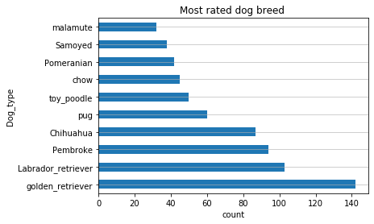

```python
#Plot the top 10 most reviewed dog breeds
df_dog_type = df_twitter.groupby('dog_type').filter(lambda x: len(x) >= 32)

df_dog_type['dog_type'].value_counts().plot(kind= 'barh')
plt.title('Most rated dog breed ')
plt.xlabel('count')
plt.ylabel('Dog_type')
plt.grid(axis='y', alpha=0.75)

fig = plt.gcf()
fig.savefig('plot.png',bbox_inches='tight');
```

> Insight# 1 Golden retriever seems to be the most reviewed dog in the entire dataframe.

```python
df_twitter[['dog_type', 'rating']].sort_values('rating').mean
```

```
<bound method DataFrame.mean of                             dog_type  rating
426   American_Staffordshire_terrier     0.0
1540              miniature_pinscher     2.0
1225                     Maltese_dog     2.0
639                     Afghan_hound     3.0
1493                             pug     3.0
...                              ...     ...
279                         Pembroke    14.0
360             Old_English_sheepdog    14.0
361                        Chihuahua    14.0
299                   French_bulldog    14.0
648                       Eskimo_dog    14.0

[1625 rows x 2 columns]>
```

```python
dog_type_mean = df_twitter.groupby('dog_type').mean()
```

```python
dog_type_mean.sort_values('rating')
```

| dog_type | tweet_id | rating_numerator | rating_denominator | day | month | year | rating | favorite_count | retweet_count | followers_count | friends_count |
| --- | --- | --- | --- | --- | --- | --- | --- | --- | --- | --- | --- |
| Japanese_spaniel | 6.773010e+17 | 5.000000 | 10.000000 | 17.000000 | 12.000000 | 2015.000000 | 5.000000 | 1201.000000 | 390.000000 | 8.841351e+06 | 17.0 |
| Afghan_hound | 8.095999e+17 | 8.000000 | 10.000000 | 16.000000 | 6.000000 | 2016.500000 | 8.000000 | 11001.000000 | 3090.000000 | 8.841340e+06 | 17.0 |
| soft-coated_wheaten_terrier | 7.038616e+17 | 20.800000 | 21.333333 | 16.666667 | 6.400000 | 2015.666667 | 8.800000 | 2994.800000 | 904.733333 | 8.841356e+06 | 17.0 |
| Walker_hound | 7.333173e+17 | 9.000000 | 10.000000 | 12.600000 | 7.600000 | 2015.800000 | 9.000000 | 5910.000000 | 2302.000000 | 8.841351e+06 | 17.0 |
| Scotch_terrier | 6.892838e+17 | 9.000000 | 10.000000 | 19.000000 | 1.000000 | 2016.000000 | 9.000000 | 3215.000000 | 1081.000000 | 8.841347e+06 | 17.0 |
| ... | ... | ... | ... | ... | ... | ... | ... | ... | ... | ... | ... |
| Border_terrier | 7.933788e+17 | 12.142857 | 10.000000 | 14.428571 | 2.000000 | 2016.714286 | 12.142857 | 12331.428571 | 2938.142857 | 8.841341e+06 | 17.0 |
| Irish_setter | 7.717825e+17 | 12.333333 | 10.000000 | 22.666667 | 8.333333 | 2016.000000 | 12.333333 | 6935.666667 | 2082.666667 | 8.841342e+06 | 17.0 |
| briard | 7.700369e+17 | 12.333333 | 10.000000 | 7.666667 | 4.666667 | 2016.333333 | 12.333333 | 8569.666667 | 2565.000000 | 8.841343e+06 | 17.0 |
| Saluki | 8.315403e+17 | 12.500000 | 10.000000 | 8.250000 | 5.250000 | 2016.750000 | 12.500000 | 21980.750000 | 4440.000000 | 8.841341e+06 | 17.0 |
| Bouvier_des_Flandres | 8.612885e+17 | 13.000000 | 10.000000 | 7.000000 | 5.000000 | 2017.000000 | 13.000000 | 16285.000000 | 3847.000000 | 8.841340e+06 | 17.0 |

113 rows × 11 columns

```python
dog_type_mean['rating'].sort_values()
```

```
dog_type
Japanese_spaniel                5.000000
Afghan_hound                    8.000000
soft-coated_wheaten_terrier     8.800000
Walker_hound                    9.000000
Scotch_terrier                  9.000000
                                 ...
Border_terrier                 12.142857
Irish_setter                   12.333333
briard                         12.333333
Saluki                         12.500000
Bouvier_des_Flandres           13.000000
Name: rating, Length: 113, dtype: float64
```

```python
df_twitter['name'].value_counts()
```

```
None       483
Cooper      10
Lucy        10
Charlie     10
Oliver       9
          ...
Mattie       1
Kawhi        1
Rumble       1
Lulu         1
Marvin       1
Name: name, Length: 810, dtype: int64
```